# The idea of Dev/Ops

Modern DevOps for Systems Biologists

Jun Allard

Department of Mathematics

Department of Systems Biology

Department of Physics and Astronomy

University of California, Irvine

# Why systems biologists need Dev/Ops now

## Motivation 1 of 4: The elevation of computational and mathematical biology

A realization that dawned on me in March 2020.

Recent worldwide events have challenged the mathematical biology community.

- A global pandemic put mathematical biology, and mathematical biologists, on the world stage — predictive epidemiology, in front of policy decision-makers.
- To keep that impact and respect, our standards of rigor in **coding** have to be elevated to match our standards of rigor in **mathematics**.
- The gap is troubling, because mathematical rigor has been a point of pride in the field. It is also an opportunity.

[figure not shown]

## Motivation 2 of 4: A case where version control saved me

An early grad student convinced me to use version control: github.com/allardjun/a-typical-paper.

The plot we had

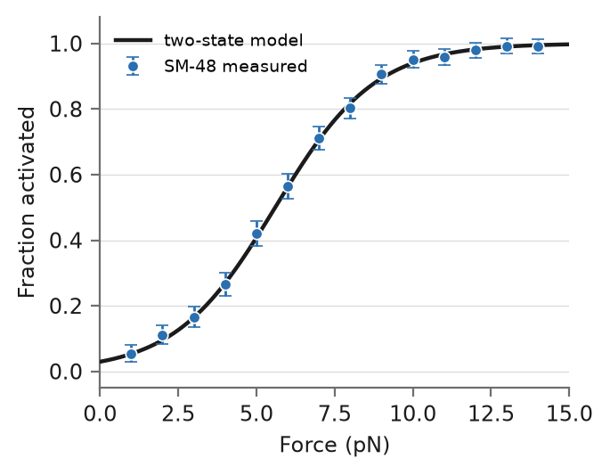

One day, while prepping the manuscript…

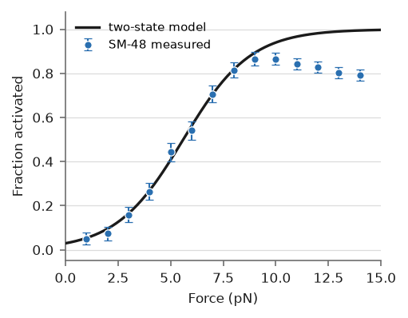

[figure not shown]

## Motivation 3 of 4: The DevOps approach to science

Software development

Develop, operate, develop, operate, develop, operate.

[figure not shown]

Ship something that runs, then make it better.

[figure not shown]

Building a car

Motor, chassis, wheels, frame, …

[figure not shown]

Or: first build a bicycle.

[figure not shown]

Graduate school

Bench phase, then coffee-shop phase.

[figure not shown]

The DevOps approach is to make **small-batch, continuous, end-to-end** improvements.

## Pros and cons of working this way

Cons

- **Wasteful.** You don’t use a lot of what you do. Think of the industrial revolution and assembly lines.
- **Misses the advantages of scale** that come from doing things in parallel.
- **Might invalidate statistical design** — consider a randomized control trial.
- **A lot of time spent keeping different versions organized.**

Pros

- For any complex, uncertain project (i.e., science!), **all the parts of the project gradually adapt** to achieve the goal.
- **Reduces time-to-deadline uncertainty.** Too slow or too unambitious? No problem.

[figure not shown]

- Empirically shown to **reduce worker burnout** (Humble & Kim 2018; Forsgren & Humble 2016).

So we are going to need easy, **seamless version control**.

## Motivation 4 of 4: Supervising powerful-but-unreliable team members

- At early career stages, **you write the code**.
- For many career paths — including outside science, and outside coding — you eventually **mentor, coach and supervise others**.
- Your job becomes helping them, critically testing their approaches, and catching bugs in their thinking.
- You need a tool that lets them **say what they are thinking**, lets you **revert** if necessary, and gives you an opportunity to **look over what they are contributing**.

[figure not shown]

In the age of agentic coders, the skill of **supervising** needs to be learned at earlier career stages.

# Working with your past and future self

## Version control with git

[figure not shown]

Advantage: **bisection search** for trouble. When something broke between here and there, git will help you halve the interval until you find it.

Vocabulary

- repo
- commit
- stage / add
- commit message
- commit hash
- `HEAD`
- checkout - going to a different commit

Two different things

- **git** — an open-source technology
- **GitHub** — a company

## git is already there

Git is already built in to almost all the software you interact with.

- **VSCode**, **Jupyter**, **MATLAB** — full support, already installed.
- **Microsoft Office**, **Mathematica** — it works, but misses some features.

[figure not shown]

## Directory architecture and large data

[figure not shown]

How we (the Allard group) organize a project — **three places**:

1. **Large files**, outside of git, backed up (e.g., Google Drive, Dropbox, linux server rack).
2. **Code**, in a git repo.
3. **Manuscript and figures**, in another git repo (not shared).

The three locations share each other’s commit hashes, so every figure knows which commit it came from.

You *can* put large files in the git repo and reach for `.gitignore` instead — but the three-place split is what has held up.

Version control with git can be used smoothly for entire projects — analysis and write-ups, not just code. That is what lets you take a continuous-improvement “DevOps” approach, with the pros and cons above.

## How often should you commit?

Ask what the action you just took actually was.

- Running something to get a result — `experiment`
- Adding a feature, mode or setting — `feat`
- Fixing a bug or troubleshooting — `bugfix`
- Refactoring, cleaning up or improving without adding new capabilities — `refactor`

A commit should not include more than one of those. “Make your commits more *atomic*”.

Committing is the one opportunity to slow down and think. Avoid automatic commits – this is not the time.

- In revisions, one commit per Peer Reviewer comment (e.g., `Reviewer1MajorComment3`)

# Working with a team

## git fork, clone, branch, merge, pull request

[figure not shown]

In the cloud

GitHub, and other providers: companies, university servers, …

- push, pull
- clone
- fork
- pull request

The idea of **repo ownership**: taking is free, giving requires permission.

Advantages *and* disadvantages over automatic history, like Apple Time Machine or Google Docs.

## Much we did not discuss

There is much we did not discuss.

- Branching
- Cherry-picking

# Working with the world, across teams and time

## Reproducibility, dependency, security and isolation

For your code to impact the scientific community, it should work across teams, computers, and dependency upgrades.

[figure not shown]

*“But it worked on my machine.”*

## Three levels of isolation

- Continually assuring that it works on **any** machine, for **any** person, without you helping.
- One project should not screw up another project, even on the same machine.
- One actor — human? agent? — should not screw up another actor, even on the same machine.

[figure not shown]

## Environments in Python, Conda, Julia, R and Matlab

Same idea everywhere: make a local copy of your dependencies, activate it, and *record* it so someone else can rebuild it.

Python

- Older way: a `venv`, memorialized in `requirements.txt`; someone else recreates it with `pip install -r requirements.txt`.
- Newer way: `uv.lock`; someone else recreates it with `uv run`.

Conda

- Make one and switch to it: `conda create -n myproject`, then `conda activate myproject`.
- Memorialized in `environment.yml`, written by `conda env export`; someone else recreates it with `conda env create`.

Julia

- All dependencies needed by any project on this machine live in `$JULIA_DEPOT`.
- Each project records what it needs in `Project.toml` and `Manifest.toml`.
- Someone else recreates your environment from those.

[figure not shown]

## Containerization: Docker and dev-containers

Some different things

- **containers** — an open-source technology
- **Docker** — a company
- **dev-container** — the VSCode/GitHub/Microsoft specification for containers

The definition of the machine lives in a `Dockerfile` or in `.devcontainer/devcontainer.json`.

They are shorter than you might guess, because they layer on top of other people’s definitions:

[figure not shown]

```json
"image": "mcr.microsoft.com/devcontainers/python:1-3.13-bookworm",
```

Both the **Our Story** activity and **Activity 2** take place in containers. You can read their `.devcontainer/devcontainer.json` to see exactly how little is in there.

## The four kinds of documentation, and the primacy of `QUICKSTART.md`

The standard classification of the [kinds of documentation](https://diataxis.fr/) that good coders use:

- references
- tutorials
- how-tos
- explanations

One kind of how-to is `QUICKSTART.md`: instructions for someone else, starting from recreating the environment and ending at a generated output, e.g. a plot.

````markdown
# QUICKSTART

Install [uv](https://docs.astral.sh/uv/) and then run:

```bash
uv sync
uv run python generate_kinetics_versus_length.py
```

This will generate `fig_kinetics.png`.
````

Keep `QUICKSTART.md` continuously up to date - know that someone else could run it without you — and you will find yourself at peace. It eliminates the “heroics” and “heist mode” at the end of a project.

## Much we did not discuss

There is much we did not discuss.

- Attribution, licensing (“Creative Commons”, “MIT”, “GPL”), confidentiality and harvesting and Open Science.
- What makes a good commit message?
- What makes a good end-to-end test? How do you come up with good end-to-end tests?